# MS4S09 ASSIGNMENT - AMAZON BOOK REVIEW ANALYSIS (30074879)

### identify the most frequently mentioned named entities overall or within specific categories in your book reviews_text

```r
# Filter named entity annotations for specific categories (if applicable)
# For example, if you want to focus on PERSON entities (characters), you can filter them like this:
character_entities <- entities %>%
  filter(entity == "PERSON_B")

# Calculate the frequency of each named entity
character_freq <- character_entities %>%
  group_by(token) %>%
  summarise(freq = n()) %>%
  arrange(desc(freq))

# Display the top entities
top_character_entities <- head(character_freq, 10)  # You can adjust the number as needed
print(top_character_entities)
```

```
## # A tibble: 10 × 2
##    token     freq
##    <chr>    <int>
##  1 David        7
##  2 Jesus        6
##  3 Anne         5
##  4 John         5
##  5 Nora         5
##  6 Java         4
##  7 Jim          4
##  8 Nicholas     4
##  9 Paul         4
## 10 Thomas       4
```

### visualizing the identified most frequently mentioned named entities in the data set

```r
# Load required libraries
library(dplyr)
library(ggplot2)


# Filter named entity annotations for specific categories (if applicable)
# For example, if you want to focus on PERSON entities (characters), you can filter them like this:
character_entities <- entities %>%
  filter(entity == "PERSON_B")  # Include both PERSON_I and PERSON_B

# Calculate the frequency of each named entity
character_freq <- character_entities %>%
  group_by(token) %>%
  summarise(freq = n()) %>%
  arrange(desc(freq))

# Display the top entities
top_character_entities <- head(character_freq, 10)  # You can adjust the number as needed
print(top_character_entities)
```

```
## # A tibble: 10 × 2
##    token     freq
##    <chr>    <int>
##  1 David        7
##  2 Jesus        6
##  3 Anne         5
##  4 John         5
##  5 Nora         5
##  6 Java         4
##  7 Jim          4
##  8 Nicholas     4
##  9 Paul         4
## 10 Thomas       4
```

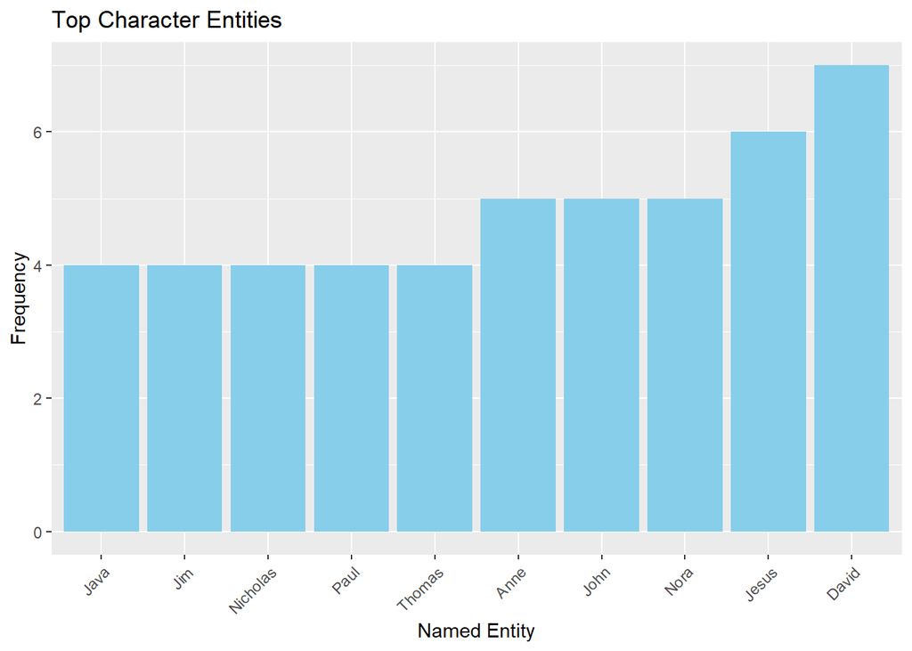

```r
# Visualize the top entities
ggplot(top_character_entities, aes(x = reorder(token, freq), y = freq)) +
  geom_bar(stat = "identity", fill = "skyblue") +
  labs(x = "Named Entity", y = "Frequency", title = "Top Character Entities") +
  theme(axis.text.x = element_text(angle = 45, hjust = 1))
```

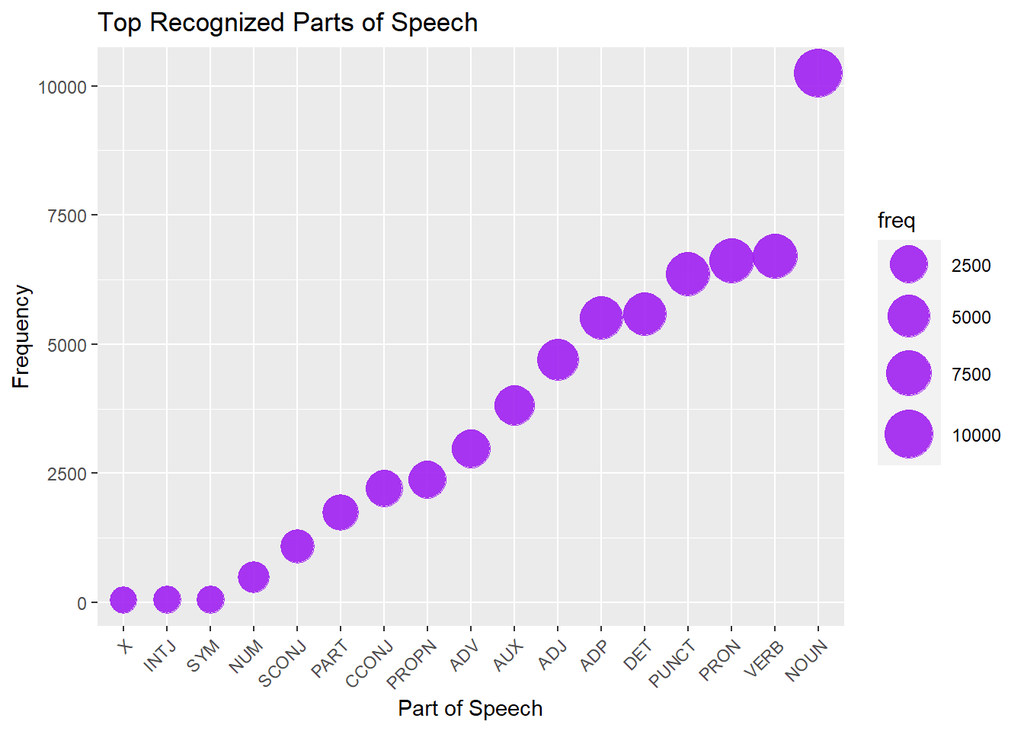

```r
# Load required libraries
library(dplyr)
library(ggplot2)



# Calculate the frequency of each part of speech
pos_freq <- entities %>%
  group_by(pos) %>%
  summarise(freq = n()) %>%
  arrange(desc(freq))

# Display the top parts of speech
# Visualize the top parts of speech in a bubble chart
ggplot(pos_freq, aes(x = reorder(pos, freq), y = freq, size = freq)) +
  geom_point(color = "purple", alpha = 0.9) +
  scale_size_continuous(range = c(6, 11)) +  # Adjust the range for bubble sizes
  labs(x = "Part of Speech", y = "Frequency", title = "Top Recognized Parts of Speech") +
  theme(axis.text.x = element_text(angle = 45, hjust = 1))
```

### Addittional models - (Time Series)

```r
filepath <- 'C:\\Users\\Gabriel Obot\\Desktop\\R-Data mining course work\\MS4S09_CW_Book_Reviews.csv'
sampled_books <- as_tibble(read.csv(filepath, stringsAsFactors = FALSE)) # Since we have text data we do not want this read as a factor

print(colnames(sampled_books))
```

```
##  [1] "Title"               "Book_Price"          "Reviewer_id"
##  [4] "Rating"              "Time"                "Review_title"
##  [7] "Review_text"         "Found_helpful_ratio" "Publisher"
## [10] "First_author"        "Genre"
```

```r
dim(sampled_books)
```

```
## [1] 59296    11
```

```r
library(stringr)

# Selecting relevant features
sampled_books <- sampled_books %>%
  select(c( "Title", "Book_Price", "Reviewer_id", "Rating", "Time", "Review_title",
 "Review_text", "Found_helpful_ratio", "Publisher", "First_author", "Genre" )) %>%
  filter(str_count(Review_text) >= 200 & str_count(Review_text) <= 400)

# Replace values of "unknown" in Genre with NA
sampled_books$Genre <- na_if(sampled_books$Genre, "unknown")

# Remove rows with missing values
book_reviews <- na.omit(book_reviews)

# Add a column for book numbers
book_reviews$book_no <- 1:nrow(book_reviews)

# Sample 1000 rows if there are more than 1000
if(nrow(sampled_books) > 1000) {
  set.seed(1)
  sampled_books <- sample_n(sampled_books, 1000)
}
```

```r
dim(sampled_books)
```

```
## [1] 1000   11
```

```r
# Convert Unix timestamp to POSIXct
sampled_books$Time <- as.POSIXct(as.numeric(sampled_books$Time), origin = "1970-01-01")

# Check the converted Time column
head(sampled_books$Time)
```

```
## [1] "2011-03-11 00:00:00 GMT" "2006-11-17 00:00:00 GMT"
## [3] "2003-11-16 00:00:00 GMT" "2007-07-04 01:00:00 BST"
## [5] "2012-08-30 01:00:00 BST" "2013-01-09 00:00:00 GMT"
```

### Original date format

```r
# Extract date part
sampled_books$Date <- as.Date(sampled_books$Time)

# Check the new Date column
head(sampled_books$Date)
```

```
## [1] "2011-03-11" "2006-11-17" "2003-11-16" "2007-07-04" "2012-08-30"
## [6] "2013-01-09"
```

```r
head(sampled_books$Date)
```

```
## [1] "2011-03-11" "2006-11-17" "2003-11-16" "2007-07-04" "2012-08-30"
## [6] "2013-01-09"
```

```r
print(colnames(sampled_books))
```

```
##  [1] "Title"               "Book_Price"          "Reviewer_id"
##  [4] "Rating"              "Time"                "Review_title"
##  [7] "Review_text"         "Found_helpful_ratio" "Publisher"
## [10] "First_author"        "Genre"               "Date"
```

## Additional model - time series

### Plot of review text monthly

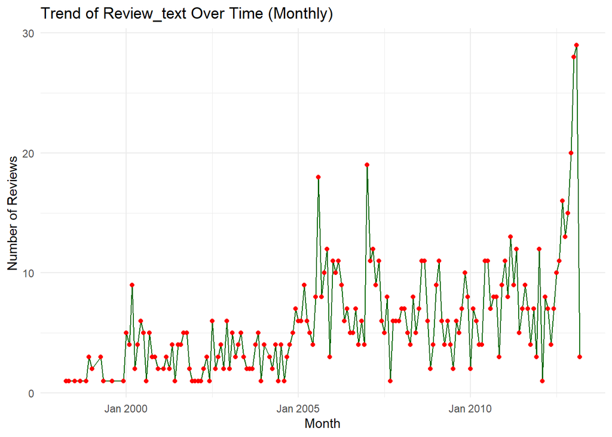

```r
# Load necessary libraries
library(dplyr)
library(ggplot2)
library(zoo)
# Convert 'Date' column to date format
sampled_books$Date <- as.Date(sampled_books$Date)

# Extract months from the 'Date' column
sampled_books$Month <- as.yearmon(sampled_books$Date)

# Create a summary of the number of reviews each month
reviews_by_month <- sampled_books %>%
  group_by(Month) %>%
  summarise(Review_count = n())

# Visualize trend of Review_text over time (monthly)
ggplot(reviews_by_month, aes(x = Month, y = Review_count)) +
  geom_line(color = "darkgreen") +
  geom_point(color = "red") +
  labs(title = "Trend of Review_text Over Time (Monthly)",
       x = "Month",
       y = "Number of Reviews") +
  theme_minimal()
```

### additional model - Linear regression model

```r
# Perform linear regression
# Perform linear regression
lm_model <- lm(Rating ~ Book_Price, data = sampled_books)

# Summary of the linear regression model
summary(lm_model)
```

```
##
## Call:
## lm(formula = Rating ~ Book_Price, data = sampled_books)
##
## Residuals:
##     Min      1Q  Median      3Q     Max
## -3.3636 -0.3369  0.6551  0.6679  1.1302
##
## Coefficients:
##              Estimate Std. Error t value Pr(>|t|)
## (Intercept)  4.366728   0.049101  88.934   <2e-16 ***
## Book_Price  -0.002105   0.001589  -1.325    0.185
## ---
## Signif. codes:  0 '***' 0.001 '**' 0.01 '*' 0.05 '.' 0.1 ' ' 1
##
## Residual standard error: 1.171 on 998 degrees of freedom
## Multiple R-squared:  0.001757,   Adjusted R-squared:  0.0007565
## F-statistic: 1.756 on 1 and 998 DF,  p-value: 0.1854
```

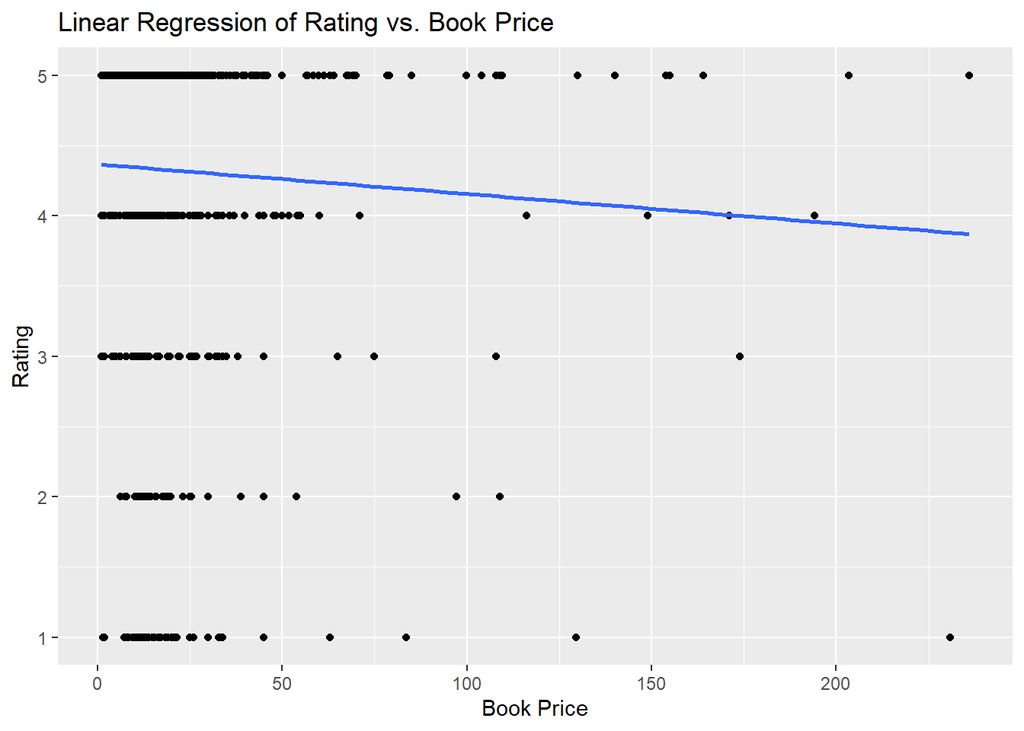

```r
library(ggplot2)

# Plot linear regression
ggplot(sampled_books, aes(x = Book_Price, y = Rating)) +
  geom_point() +  # Scatter plot of the data points
  geom_smooth(method = "lm", se = FALSE) +  # Add linear regression line
  labs(x = "Book Price", y = "Rating", title = "Linear Regression of Rating vs. Book Price")
```

Based on the results of the linear regression analysis, it can be concluded that there is insufficient evidence to support a significant linear relationship between the variables Book_Price and Rating. The coefficient for Book_Price was found to be not statistically significant, indicating that changes in Book_Price are not associated with significant changes in Rating. Additionally, the low R-squared value suggests that Book_Price explains very little of the variability observed in Rating. Overall, these findings suggest that other factors beyond Book_Price likely play a more substantial role in determining the Rating of the books.

**Discussion of future work**

In considering future work based on our sentiment analysis findings, there are several exciting directions that could be explored. We could delve deeper into improving the accuracy of sentiment analysis by trying out more advanced machine learning techniques or neural network models.

It would be fascinating to see how sentiment analysis performs in different languages or cultural contexts, which could give us a broader understanding of how people express emotions through text. Moreover, we could combine sentiment analysis with other natural language processing tasks like topic modeling or named entity recognition to uncover more nuanced insights from text data. Imagine tracking changes in sentiment over time or analyzing sentiments in real-time social media posts to see how opinions evolve or respond to current events. Lastly, investigating how sentiment impacts real-world outcomes such as customer behavior or product sales could have significant implications for industries like marketing and public relations.

As we delve deeper into the realm of AI and Natural Language Processing (NLP), it’s imperative to consider the ethical and security implications inherent in these technologies. With the increasing reliance on AI-driven systems to analyze and interpret vast amounts of textual data, the issue of data biases becomes paramount. We must actively work to mitigate biases in our datasets to ensure that our NLP models provide fair and unbiased results across diverse demographic groups. Moreover, as AI continues to evolve, the risk of cyber attacks exploiting vulnerabilities in data and NLP systems grows as well. Safeguarding against these threats requires robust security measures and continuous vigilance to protect sensitive information and maintain the integrity of NLP technologies. Additionally, ensuring user privacy and responsible deployment of NLP tools are essential considerations. By addressing these ethical and security challenges head-on, we can foster trust in AI technologies and pave the way for their responsible and beneficial integration into various aspects of society.